# DAG & variable coding

M. Rolland

21/01/2021

# Intro

Here we present the final DAG for the babylab analysis and decide which covariates will be used in the final models. Then we decide on the appropriate coding. And finally we select variables according to p-value (<0.2) to present the final model.

We used a mixed effect model as discussed in the `model_validation.html` document with **fixation duration** as the outcome.

# DAG

Produced by M. Rolland and C. Philippat version of 27/11/2020:

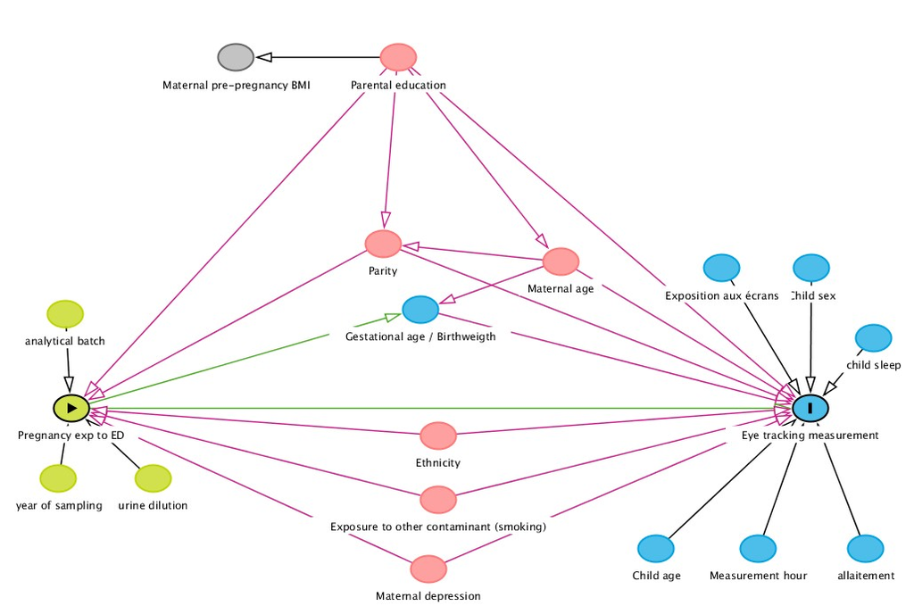

According to the DAG the analysis confounders are:

- Ethnicity
- Maternal age at conception
- Exposure to other contaminant (tobacco)
- Maternal depression
- Parental education
- Parity

In addition to these covariates we add experiment hour which is suspected to be a strong predictor of the outcome (see `data_exploration.html`). Other outcome predictors (in blue on the DAG) are not considered as they are poorly measured in Sepages with many NAs. Child age is colinear with age at assessment so cannot be included in the mixed effect model.

Child sex will also be added. **WHY?**

Gestational age and birthweight are on the pathway so won’t be included in the main analysis, but will be added in the sensitivity analyses.

# Choice of tobacco indicator

Only for tobacco the choice of the indicator to use is not straight forward as we have several types of indicator (contiunous, binary) at different periods of time (whole pregnancy, T1, T2, etc).

Given the low number of smokers in sepages, we will not consider the continuous variables or the binary indicators for high consumption, we will only consider the binary indicators indicating whether the participant smoked/did not smoke in a given time frame.

Tobacco indicators:

| var | label | n_na | smoking |
| --- | --- | --- | --- |
| mo_tob_grstt1_yn | Maternal smoking between preg. conception and detection, N/Y | 8 | 21 / 180 |
| mo_tob_grt1_yn | Maternal smoking during 1st trim of pregnancy, after diagnosis, N/Y | 8 | 7 / 180 |
| mo_tob_grt2_yn | Maternal smoking during 2nd trim of pregnancy, N/Y | 5 | 6 / 183 |
| mo_tob_grt3_yn | Maternal smoking during 3rd trim of pregnancy, N/Y | 16 | 4 / 172 |
| mo_tob_gr_anyt_yn | Maternal smoking during any trim of diagnosed pregnancy, N/Y | 12 | 10 / 176 |
| mo_tob_granyt_yn_recalc | NA | 7 | 24 / 181 |

- very few smokers at T3
- many missing for T3 and the any time during pregnancy (after detection) variables
  - **will not consider smoking at T3 and any time during pregnancy after detection (instead we will consider any time during pregnancy including between conception and detection)**

Tobacco model with different tobacco vars adjusted on the other covars **limited to data with no missing for smoking pre detection, at T1, at T2 and any time since conception** ordered by decreasing beta (including recalculated smoked any time after conception yes/no):

| var | Coefficient | CI_low | CI_high | p |
| --- | --- | --- | --- | --- |
| mo_tob_granyt_yn_recalc | 14.421803 | -9.604816 | 38.44842 | 0.2394135 |
| mo_tob_grstt1_yn | 14.421803 | -9.604816 | 38.44842 | 0.2394135 |
| mo_tob_grt1_yn | 1.306971 | -44.205552 | 46.81949 | 0.9551157 |
| mo_tob_grt2_yn | -3.822231 | -54.897144 | 47.25268 | 0.8833882 |

- highest beta for smoking pre-detection *and* any time
- we will favor smoked any time (easier to interpret)

# Variable description

Data Frame Summary

**desc_data**  
**Dimensions**: 188 x 11  
**Duplicates**: 0

| **No** | **Variable** | **Label** | **Stats / Values** | **Freqs (% of Valid)** | **Graph** | **Missing** |
| --- | --- | --- | --- | --- | --- | --- |
| 1 | sexe [factor] |  | 1. 1 2. 2 | 105 ( 55.9% ) 83 ( 44.1% ) |  | 0 (0.0%) |
| 2 | mo_edu [factor] |  | 1. 8 2. 3 3. 4 4. 5 5. 6 6. 7 | 104 ( 55.9% ) 2 ( 1.1% ) 4 ( 2.2% ) 2 ( 1.1% ) 18 ( 9.7% ) 56 ( 30.1% ) |  | 2 (1.1%) |
| 3 | mo_age [numeric] | Maternal age at conception, years | Mean (sd) : 32.2 (3.9) min < med < max: 22.5 < 31.8 < 45.5 IQR (CV) : 4.9 (0.1) | 184 distinct values |  | 0 (0.0%) |
| 4 | parity [factor] |  | 1. 0 2. 1 3. 2 | 90 ( 47.9% ) 81 ( 43.1% ) 17 ( 9.0% ) |  | 0 (0.0%) |
| 5 | ethnicity [numeric] | De quelle origine ethnique vous considérez-vous ? | Mean (sd) : 5.6 (12.2) min < med < max: 2 < 4 < 99 IQR (CV) : 0 (2.2) | 2 : 1 ( 0.6% ) 3 : 1 ( 0.6% ) 4 : 172 ( 96.1% ) 5 : 1 ( 0.6% ) 7 : 1 ( 0.6% ) 99 : 3 ( 1.7% ) |  | 9 (4.8%) |
| 6 | tobacco [numeric] |  | Min : 0 Mean : 0.1 Max : 1 | 0 : 157 ( 86.7% ) 1 : 24 ( 13.3% ) |  | 7 (3.7%) |
| 7 | birth_weight [numeric] | Birth weight (child), g | Mean (sd) : 3285.4 (406.2) min < med < max: 2070 < 3270 < 4670 IQR (CV) : 462.5 (0.1) | 106 distinct values |  | 0 (0.0%) |
| 8 | gest_age [numeric] | Gestational duration, completed weeks | Mean (sd) : 39.3 (1.4) min < med < max: 33 < 40 < 41 IQR (CV) : 1 (0) | 33 : 2 ( 1.1% ) 35 : 1 ( 0.5% ) 36 : 6 ( 3.2% ) 37 : 9 ( 4.8% ) 38 : 28 ( 14.9% ) 39 : 43 ( 22.9% ) 40 : 67 ( 35.6% ) 41 : 32 ( 17.0% ) |  | 0 (0.0%) |
| 9 | mo_anx [numeric] |  | Mean (sd) : 6.2 (2.7) min < med < max: 0 < 6 < 16 IQR (CV) : 4 (0.4) | 15 distinct values |  | 4 (2.1%) |
| 10 | mo_dep [numeric] |  | Mean (sd) : 4 (2.8) min < med < max: 0 < 3 < 14 IQR (CV) : 3 (0.7) | 14 distinct values |  | 4 (2.1%) |
| 11 | mo_had [numeric] |  | Mean (sd) : 10.2 (4.5) min < med < max: 2 < 10 < 25 IQR (CV) : 6 (0.4) | 23 distinct values |  | 4 (2.1%) |

# Variable coding

Need to decide how to group the categories of the following categorical variables: **education** and **parity**. And need to decide whether to include as continuous or categorical the following continuous variables: **mat age**, **mat education** and **experiment time**.

## Categorical variables

### Maternal education

```
## Parameter          | Coefficient |     SE |            95% CI | t(226) |      p
## -------------------------------------------------------------------------------
## (Intercept)        |      237.00 |  60.91 | [ 117.62, 356.37] |   3.89 | < .001
## edu [<=bac]        |       -8.34 |  20.22 | [ -47.97,  31.29] |  -0.41 | 0.680
## edu [bac+1-2]      |       -7.18 |  12.55 | [ -31.77,  17.41] |  -0.57 | 0.567
## edu [bac+3-4]      |       -1.74 |   8.56 | [ -18.52,  15.04] |  -0.20 | 0.839
## sexe [2]           |       -3.80 |   7.64 | [ -18.78,  11.18] |  -0.50 | 0.619
## parity [1]         |        7.30 |   8.20 | [  -8.76,  23.36] |   0.89 | 0.373
## parity [2]         |       20.59 |  14.25 | [  -7.34,  48.52] |   1.44 | 0.149
## tobacco            |       19.85 |  11.59 | [  -2.86,  42.56] |   1.71 | 0.087
## mo_age             |        2.04 |   1.01 | [   0.06,   4.01] |   2.02 | 0.043
## had_cat2 [>11]     |       10.45 |   8.45 | [  -6.11,  27.01] |   1.24 | 0.216
## exp_t [1st degree] |       52.94 |  49.66 | [ -44.39, 150.27] |   1.07 | 0.286
## exp_t [2nd degree] |      -10.12 |  33.39 | [ -75.56,  55.32] |  -0.30 | 0.762
## exp_t [3rd degree] |      100.64 | 109.06 | [-113.12, 314.39] |   0.92 | 0.356
## exp_t [4th degree] |       28.87 |  24.29 | [ -18.74,  76.48] |   1.19 | 0.235
## age_cat [5]        |       63.48 |   8.43 | [  46.97,  80.00] |   7.53 | < .001
## age_cat [12]       |       32.61 |   6.20 | [  20.47,  44.76] |   5.26 | < .001
```

- Given betas would further regroup maternal edu bac+1-2 with <=bac abd bac+3-4 with >=bac+5

### Parity

[output not shown]

- Parity 2 higher beta, would leave as is (no sense in 0 or 1 and 2+…), will probably not be selected in any of the final models

## Continuous variables

### Maternal age

```
## Parameter              | Coefficient |     SE |           95% CI | t(227) |      p
## ----------------------------------------------------------------------------------
## (Intercept)            |      282.57 |  52.46 | [179.75, 385.39] |   5.39 | < .001
## edu2 [<=bac+2]         |       -8.54 |  10.83 | [-29.75,  12.68] |  -0.79 | 0.430
## sexe [2]               |       -3.09 |   7.54 | [-17.86,  11.68] |  -0.41 | 0.682
## parity [1]             |        7.12 |   8.13 | [ -8.82,  23.06] |   0.88 | 0.382
## parity [2]             |       18.85 |  14.13 | [ -8.85,  46.55] |   1.33 | 0.182
## tobacco                |       18.78 |  11.60 | [ -3.96,  41.51] |   1.62 | 0.106
## mo_age_cat [30.9-32.1] |        7.18 |  10.41 | [-13.23,  27.59] |   0.69 | 0.491
## mo_age_cat [33.1-35.2] |       20.87 |  10.55 | [  0.19,  41.54] |   1.98 | 0.048
## mo_age_cat [36.2-45.5] |       21.52 |  11.30 | [ -0.62,  43.66] |   1.91 | 0.057
## had_cat2 [>11]         |       10.40 |   8.38 | [ -6.04,  26.83] |   1.24 | 0.215
## exp_t [1st degree]     |       60.33 |  49.69 | [-37.06, 157.72] |   1.21 | 0.225
## exp_t [2nd degree]     |       -4.62 |  33.26 | [-69.81,  60.57] |  -0.14 | 0.890
## exp_t [3rd degree]     |      117.01 | 109.10 | [-96.83, 330.84] |   1.07 | 0.284
## exp_t [4th degree]     |       31.56 |  24.18 | [-15.83,  78.95] |   1.31 | 0.192
## age_cat [5]            |       63.43 |   8.39 | [ 46.99,  79.86] |   7.56 | < .001
## age_cat [12]           |       32.40 |   6.15 | [ 20.35,  44.45] |   5.27 | < .001
```

- Increases with age, keep as continuous

### Maternal depression

```
## Parameter          | Coefficient |     SE |            95% CI | t(226) |      p
## -------------------------------------------------------------------------------
## (Intercept)        |      236.69 |  60.87 | [ 117.37, 356.00] |   3.89 | < .001
## edu2 [<=bac+2]     |       -5.89 |  10.85 | [ -27.17,  15.38] |  -0.54 | 0.587
## sexe [2]           |       -4.85 |   7.68 | [ -19.90,  10.21] |  -0.63 | 0.528
## parity [1]         |        7.50 |   8.20 | [  -8.57,  23.56] |   0.91 | 0.360
## parity [2]         |       20.73 |  14.35 | [  -7.40,  48.86] |   1.44 | 0.149
## tobacco            |       19.63 |  11.70 | [  -3.30,  42.56] |   1.68 | 0.093
## mo_age             |        2.08 |   1.01 | [   0.10,   4.07] |   2.06 | 0.039
## had_cat [7-9]      |        6.98 |  11.09 | [ -14.76,  28.72] |   0.63 | 0.529
## had_cat [10-11]    |       -1.30 |  12.02 | [ -24.87,  22.26] |  -0.11 | 0.914
## had_cat [12-14.6]  |       14.54 |  13.87 | [ -12.64,  41.73] |   1.05 | 0.294
## had_cat [15.6-37]  |       11.28 |  12.67 | [ -13.55,  36.11] |   0.89 | 0.373
## exp_t [1st degree] |       48.81 |  49.99 | [ -49.17, 146.78] |   0.98 | 0.329
## exp_t [2nd degree] |      -10.82 |  33.38 | [ -76.25,  54.61] |  -0.32 | 0.746
## exp_t [3rd degree] |       92.36 | 109.98 | [-123.19, 307.92] |   0.84 | 0.401
## exp_t [4th degree] |       26.13 |  24.43 | [ -21.74,  74.01] |   1.07 | 0.285
## age_cat [5]        |       63.54 |   8.40 | [  47.08,  80.00] |   7.57 | < .001
## age_cat [12]       |       32.57 |   6.17 | [  20.48,  44.66] |   5.28 | < .001
```

- not linear but could be consistant with a cutoff at 11 see https://pubmed.ncbi.nlm.nih.gov/21898134/
- would choose <=11 / >11

### Experiment hour

We have seen that there seems to be a non linear relationship between experiment hour and some of the scores (see `data_exploration.html`).

Model with maximum possible number of categories:

- 8 (N = 1) & 9 (N = 56)
- 10 (N = 47)
- 11 (N = 18)
- 12 (N = 2) & 13 (N = 5) & 14 (N = 3)
- 15 (N = 11)
- 16 (N = 8)

```
## Parameter            | Coefficient |    SE |           95% CI | t(228) |      p
## -------------------------------------------------------------------------------
## (Intercept)          |      286.68 | 31.74 | [224.47, 348.88] |   9.03 | < .001
## edu2 [<=bac+2]       |       -6.89 | 10.78 | [-28.01,  14.24] |  -0.64 | 0.523
## sexe [2]             |       -5.14 |  7.55 | [-19.94,   9.67] |  -0.68 | 0.497
## parity [1]           |        7.49 |  8.16 | [ -8.49,  23.48] |   0.92 | 0.358
## parity [2]           |       20.09 | 14.14 | [ -7.63,  47.81] |   1.42 | 0.155
## tobacco              |       21.35 | 11.56 | [ -1.31,  44.02] |   1.85 | 0.065
## mo_age               |        2.15 |  0.99 | [  0.20,   4.10] |   2.16 | 0.030
## had_cat2 [>11]       |       11.35 |  8.35 | [ -5.01,  27.71] |   1.36 | 0.174
## exp_t_cat [10]       |        0.96 |  7.66 | [-14.05,  15.98] |   0.13 | 0.900
## exp_t_cat [11]       |      -23.54 |  9.98 | [-43.10,  -3.97] |  -2.36 | 0.018
## exp_t_cat [12-13-14] |       -5.29 | 11.49 | [-27.81,  17.23] |  -0.46 | 0.645
## exp_t_cat [15]       |      -17.32 | 12.29 | [-41.40,   6.76] |  -1.41 | 0.159
## exp_t_cat [16]       |       16.03 | 15.38 | [-14.12,  46.18] |   1.04 | 0.297
## age_cat [5]          |       65.27 |  8.26 | [ 49.08,  81.45] |   7.90 | < .001
## age_cat [12]         |       33.61 |  6.08 | [ 21.70,  45.52] |   5.53 | < .001
```

- Not linear
- We compare these different options based on AIC:
  - classification A
    - 8-9-10
    - 11
    - 12-13-14
    - 15
    - 16
  - classification B
    - 8-9-10
    - 11
    - 12-13-14-15
    - 16
  - classification C
    - 8-9-10
    - 11-12-13-14-15
    - 16
  - spline with 4 df

AIC for the different options:

- AIC(classif A): 2533
- AIC(classif A): 2539
- AIC(classif A): 2545
- AIC(spline): 2532

Best = spline with 4 df.

### Final model

```
## Parameter          | Coefficient |     SE |            95% CI | t(229) |      p
## -------------------------------------------------------------------------------
## (Intercept)        |      237.34 |  60.18 | [ 119.38, 355.30] |   3.94 | < .001
## edu2 [<=bac+2]     |       -6.91 |  10.70 | [ -27.88,  14.05] |  -0.65 | 0.518
## sexe [2]           |       -3.91 |   7.52 | [ -18.66,  10.84] |  -0.52 | 0.603
## parity [1]         |        7.34 |   8.11 | [  -8.56,  23.25] |   0.90 | 0.366
## parity [2]         |       20.39 |  14.02 | [  -7.09,  47.87] |   1.45 | 0.146
## tobacco            |       19.87 |  11.48 | [  -2.63,  42.37] |   1.73 | 0.083
## mo_age             |        2.03 |   0.98 | [   0.11,   3.96] |   2.07 | 0.039
## had_cat2 [>11]     |       10.18 |   8.29 | [  -6.07,  26.43] |   1.23 | 0.220
## exp_t [1st degree] |       52.32 |  49.19 | [ -44.09, 148.72] |   1.06 | 0.287
## exp_t [2nd degree] |      -10.23 |  32.95 | [ -74.81,  54.36] |  -0.31 | 0.756
## exp_t [3rd degree] |       99.28 | 108.01 | [-112.42, 310.97] |   0.92 | 0.358
## exp_t [4th degree] |       28.38 |  24.01 | [ -18.67,  75.43] |   1.18 | 0.237
## age_cat [5]        |       63.50 |   8.37 | [  47.09,  79.91] |   7.58 | < .001
## age_cat [12]       |       32.59 |   6.16 | [  20.52,  44.65] |   5.29 | < .001
```

Significant:

- child age
- maternal age

### Wald tests

```
## Analysis of Deviance Table (Type II Wald chisquare tests)
##
## Response: fix_dur
##                Chisq Df Pr(>Chisq)
## edu2          0.4175  1    0.51818
## sexe          0.2704  1    0.60308
## parity        2.3508  2    0.30870
## tobacco       2.9964  1    0.08345 .
## mo_age        4.2803  1    0.03856 *
## had_cat2      1.5064  1    0.21968
## ns(exp_t, 4)  5.9953  4    0.19950
## age_cat      72.4522  2    < 2e-16 ***
## ---
## Signif. codes:  0 '***' 0.001 '**' 0.01 '*' 0.05 '.' 0.1 ' ' 1
```

We can further drop:

- education
- parity
- depression
- sex?

# Conclusion

Final suggested model covariates and coding after selecting for p < 0.2:

```
## Parameter          | Coefficient |     SE |           95% CI | t(236) |      p
## ------------------------------------------------------------------------------
## (Intercept)        |      221.92 |  59.12 | [106.05, 337.78] |   3.75 | < .001
## sexe [2]           |       -5.19 |   7.38 | [-19.65,   9.28] |  -0.70 | 0.482
## tobacco            |       17.79 |  11.08 | [ -3.92,  39.51] |   1.61 | 0.108
## mo_age             |        2.54 |   0.93 | [  0.73,   4.36] |   2.75 | 0.006
## exp_t [1st degree] |       58.48 |  48.82 | [-37.21, 154.18] |   1.20 | 0.231
## exp_t [2nd degree] |       -6.94 |  32.74 | [-71.11,  57.24] |  -0.21 | 0.832
## exp_t [3rd degree] |      113.96 | 107.30 | [-96.34, 324.26] |   1.06 | 0.288
## exp_t [4th degree] |       30.06 |  23.69 | [-16.38,  76.50] |   1.27 | 0.205
## age_cat [5]        |       64.01 |   8.31 | [ 47.73,  80.29] |   7.71 | < .001
## age_cat [12]       |       32.14 |   6.08 | [ 20.22,  44.05] |   5.29 | < .001
```

# Annex

## Coding reminder

- `mo_edu`
  - 1 Primaire
  - 2 College
  - 3 BEP
  - 4 CAP
  - 5 Lycee
  - 6 Bac +2
  - 7 Bac +3-4
  - 8 >=Bac +5
- `parity`
  - 0 First child
  - 1 Second child
  - 2 Third child or more

## Model diagnostic

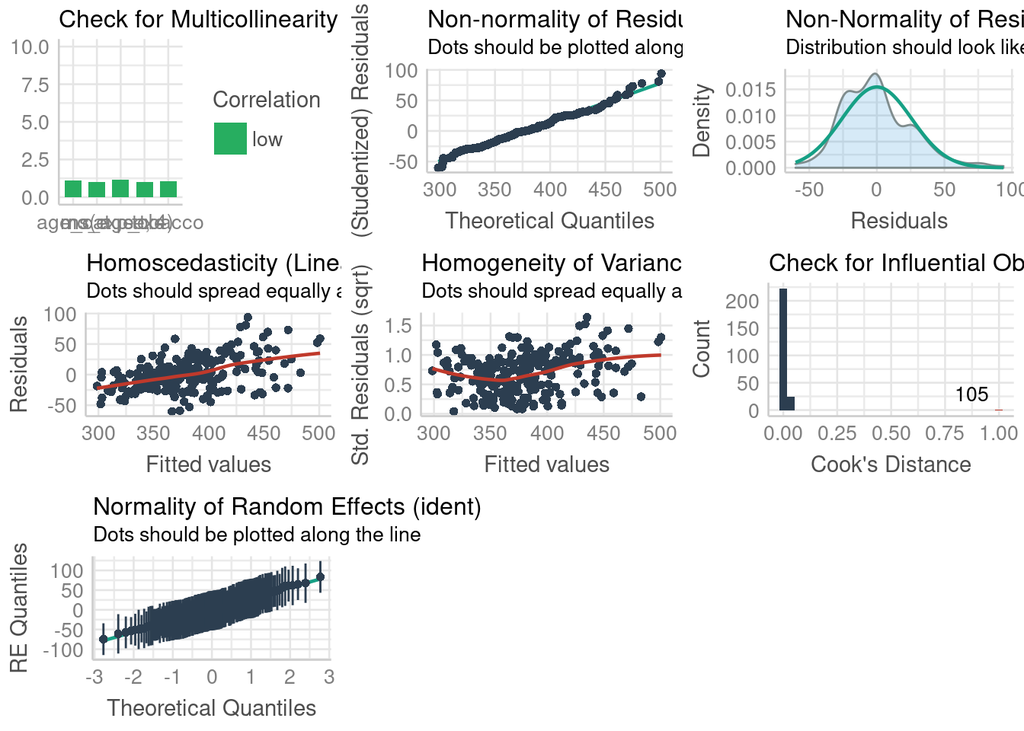